# EDA

Shuai Yuan

12/4/2023

## Code Book

- `age` - age in years
- `sex` - sex (1 = male; 0 = female)
- `cp` - chest pain type (1 = typical angina; 2 = atypical angina; 3 = non-anginal pain; 0 = asymptomatic)
- `trestbps` - resting blood pressure (in mm Hg on admission to the hospital)
- `chol` - serum cholestoral in mg/dl
- `fbs` - fasting blood sugar > 120 mg/dl (1 = true; 0 = false)
- `restecg` - resting electrocardiographic results (1 = normal; 2 = having ST-T wave abnormality; 0 = hypertrophy)
- `thalach` - maximum heart rate achieved
- `exng` - exercise induced angina (1 = yes; 0 = no)
- `oldpeak` - ST depression induced by exercise relative to rest
- `slope` - the slope of the peak exercise ST segment (2 = upsloping; 1 = flat; 0 = downsloping)
- `caa` - number of major vessels (0-3) colored by flourosopy
- `thall` - thalassemia (0 = Null; 2 = normal; 1 = fixed defect; 3 = reversable defect) [it is a kind of blood disorder]
- `output` - the predicted attribute - diagnosis of heart disease (angiographic disease status) (Value 0 = < diameter narrowing; Value 1 = > 50% diameter narrowing)

# Exploratory Data Analysis

In this section we will do some plotting to visualize the data and see if we could find some connections between variables and as well as some distributional trend.

## Data Processing

```r
setwd(data_dir)
load('heart.rda')
heart_num <- heart
```

We then take a quick look at the data. We tend to use the whole data set and we will try to find any problems in it and see what we need to exclude. In this step everything looks just fine.

```r
heart %>%
  head()
```

```
##   age sex cp trtbps chol fbs restecg thalachh exng oldpeak slp caa thall output
## 1  63   1  3    145  233   1       0      150    0     2.3   0   0     1      1
## 2  37   1  2    130  250   0       1      187    0     3.5   0   0     2      1
## 3  41   0  1    130  204   0       0      172    0     1.4   2   0     2      1
## 4  56   1  1    120  236   0       1      178    0     0.8   2   0     2      1
## 5  57   0  0    120  354   0       1      163    1     0.6   2   0     2      1
## 6  57   1  0    140  192   0       1      148    0     0.4   1   0     1      1
```

The next step, we examine at the dataset to see if there is any missing value. Luckily, there is not a single missing value! That means we do not have to worry about any of the variables becuase all of them cloud be put in use and not impeding our prediction.

```r
sum(is.na(heart))
```

```
## [1] 0
```

## Summary

We first take a look at the summary. This will give us a overall idea about the dataset. However, before we dig into it, I made some quick changes. First, I have added a new variable called `age_class` at the back which gives us better idea of the `age` variable. Also, I put all categorical variables into its form so that we could see a count in the summary sheet instead of a meaningless mean and variance, since it was all converted into number representations. (See detail in Codebook.txt or the codebook section above)

```r
heart <- heart %>%
  dplyr::mutate(gender = case_when(sex == "0" ~ "Female", sex == "1" ~ "Male"),
                output = case_when(output == "0" ~ "No", output == "1" ~ "Yes"),
                gender = factor(gender),
                cp = factor(cp),
                fbs = factor(fbs),
                restecg = factor(restecg),
                exng = factor(exng),
                caa = factor(caa),
                thall = factor(thall),
                output = factor(output),
                sex = factor(sex),
                slp = factor(slp),
                age_class = cut(age, breaks = seq(25, 80, by = 5))
                )

heart %>%
  summary
```

```
##       age        sex     cp          trtbps           chol       fbs
##  Min.   :29.00   0: 96   0:143   Min.   : 94.0   Min.   :126.0   0:258
##  1st Qu.:47.50   1:207   1: 50   1st Qu.:120.0   1st Qu.:211.0   1: 45
##  Median :55.00           2: 87   Median :130.0   Median :240.0
##  Mean   :54.37           3: 23   Mean   :131.6   Mean   :246.3
##  3rd Qu.:61.00                   3rd Qu.:140.0   3rd Qu.:274.5
##  Max.   :77.00                   Max.   :200.0   Max.   :564.0
##
##  restecg    thalachh     exng       oldpeak     slp     caa     thall
##  0:147   Min.   : 71.0   0:204   Min.   :0.00   0: 21   0:175   0:  2
##  1:152   1st Qu.:133.5   1: 99   1st Qu.:0.00   1:140   1: 65   1: 18
##  2:  4   Median :153.0           Median :0.80   2:142   2: 38   2:166
##          Mean   :149.6           Mean   :1.04           3: 20   3:117
##          3rd Qu.:166.0           3rd Qu.:1.60           4:  5
##          Max.   :202.0           Max.   :6.20
##
##  output       gender      age_class
##  No :138   Female: 96   (55,60]:72
##  Yes:165   Male  :207   (50,55]:57
##                         (60,65]:46
##                         (40,45]:45
##                         (45,50]:31
##                         (65,70]:27
##                         (Other):25
```

## Correlation

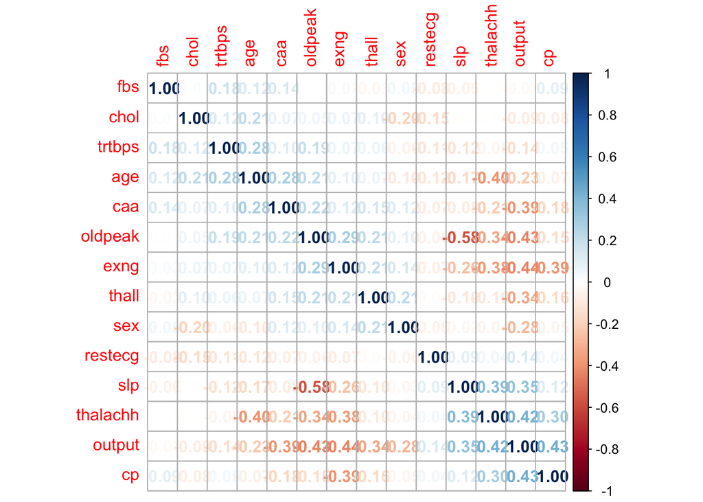

```r
graph_corr <- corrplot(cor(heart_num[,]),
                       order = "AOE",
                       method = "number")
```

From this correlation plot we can see that highest positive correlation is between `cp` and `output`, which mean chest pain might be directly leading to heart problems. The other correlation stood out is the negative correlation between `slp` and `oldpeak`. Which implies depression might be reflected in the slope of the peak exercise. Overall, correlation between variables are not very strong, this implies that building a machine learning model is necessary since we can not tell whether someone has high risk of heart attack by looking at a single variable. Also, this implies we do not have to eliminate any variables, since that all provides information in different aspects.

## Visual EDAs

### Age

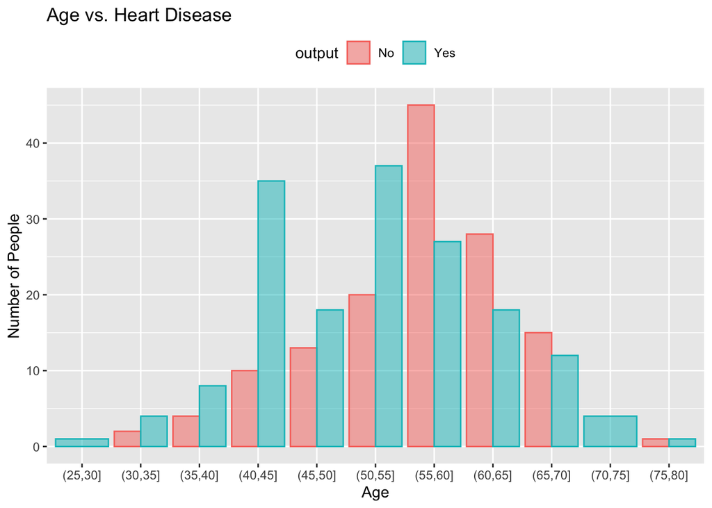

```r
ggplot(heart, aes(x=age_class, fill = output, color = output)) +
  geom_bar(position = "dodge", alpha=0.5) +
  theme(legend.position = "top") +
  labs(title = "Age vs. Heart Disease",
          x = "Age", y = "Number of People")
```

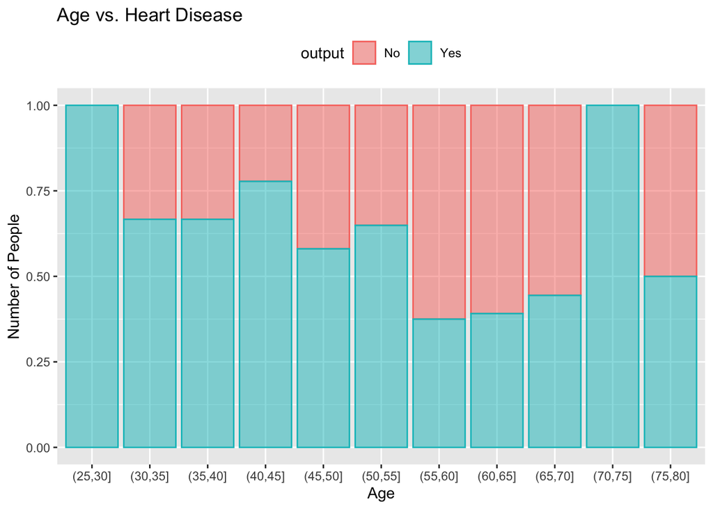

```r
ggplot(heart, aes(x=age_class, fill = output, color = output)) +
  geom_bar(position = "fill", alpha=0.5) +
  theme(legend.position = "top") +
  labs(title = "Age vs. Heart Disease",
          x = "Age", y = "Number of People")
```

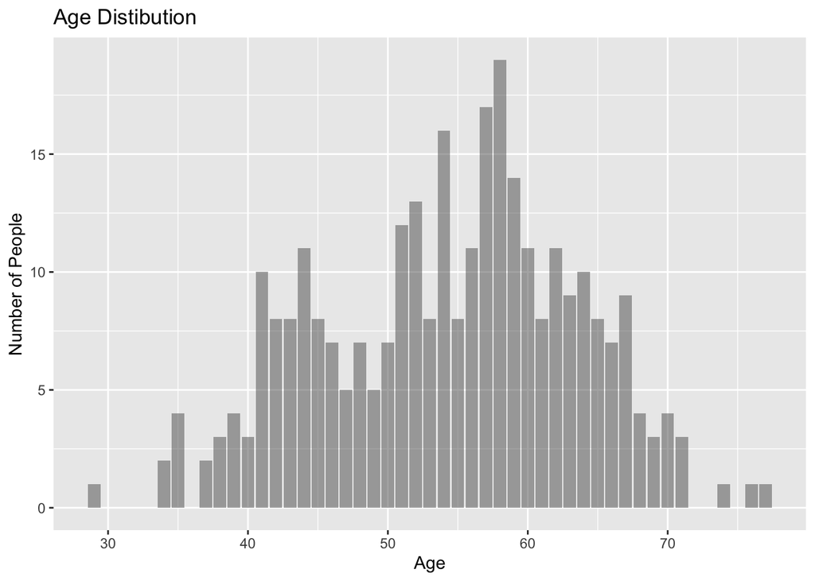

```r
ggplot(heart, aes(x=age)) +
  geom_bar(position = "dodge", alpha=0.5) +
  theme(legend.position = "top")+
  labs(title = "Age Distibution",
          x = "Age", y = "Number of People")
```

The `age` distribution is generally normally distributed, with a little bit of a left skewed. However, when we take a look at the joint graph with `age` distribution separated by outcome variable, we see that people who has low risk of heart attack is normally distribution and has mean between 55-60, while people with high risk is normally distribution except there is a high value of people in age group 40-45. As for probability of getting a higher risk, we could see that surprisingly, it seems like the younger it is, the higher risk of getting heart attack is.

### Resting blood pressure

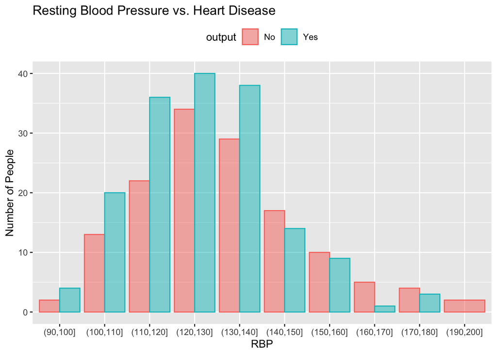

```r
heart <- heart %>%
  mutate(trtbps_class = cut(trtbps, breaks = seq(90, 200, by = 10)))
graph_trtbps <- ggplot(heart, aes(x=trtbps_class, fill = output, color = output)) +
  geom_bar(position = "dodge", alpha=0.5) +
  theme(legend.position = "top")
graph_trtbps + labs(title = "Resting Blood Pressure vs. Heart Disease",
                 x = "RBP", y = "Number of People")
```

The resting blood pressure is right skewed and does not change much due to whether what output variable is. It is most likely to be irrelevant.

### Cholestoral

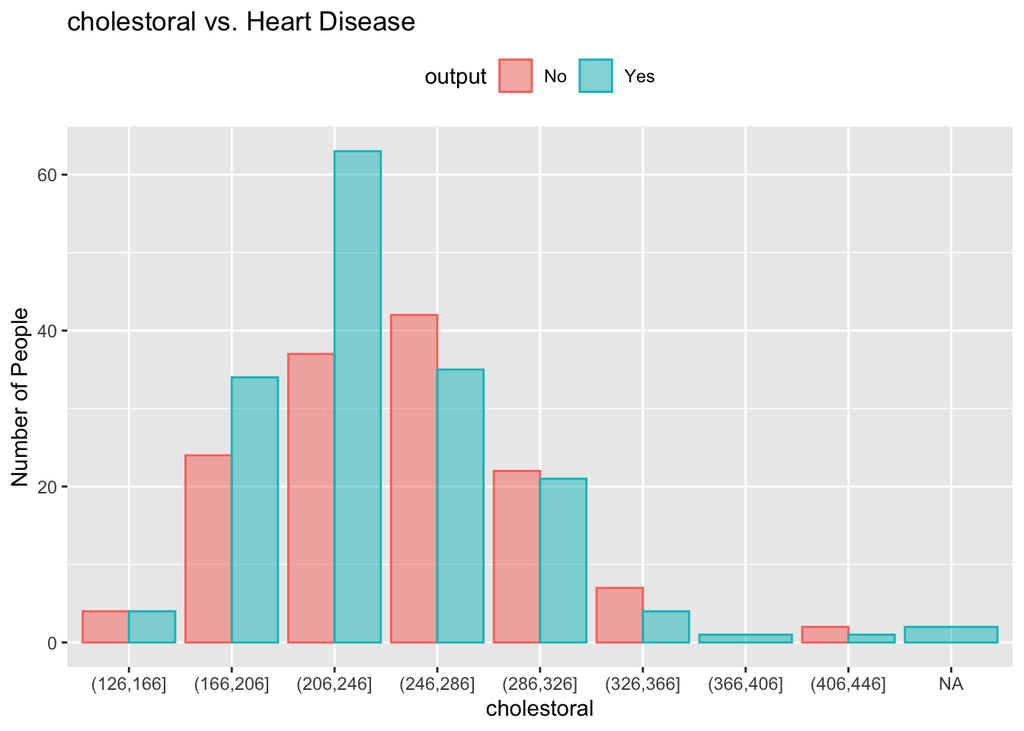

```r
heart <- heart %>%
  mutate(chol_class = cut(chol, breaks = seq(126, 564, by = 40)))
graph_chol <- ggplot(heart, aes(x=chol_class, fill = output, color = output)) +
  geom_bar(position = "dodge", alpha=0.5) +
  theme(legend.position = "top")
graph_chol + labs(title = "cholestoral vs. Heart Disease",
                    x = "cholestoral", y = "Number of People")
```

This is another right skewed variable, with not so many correlation with outcome variable.

### Maximum Heart Rate

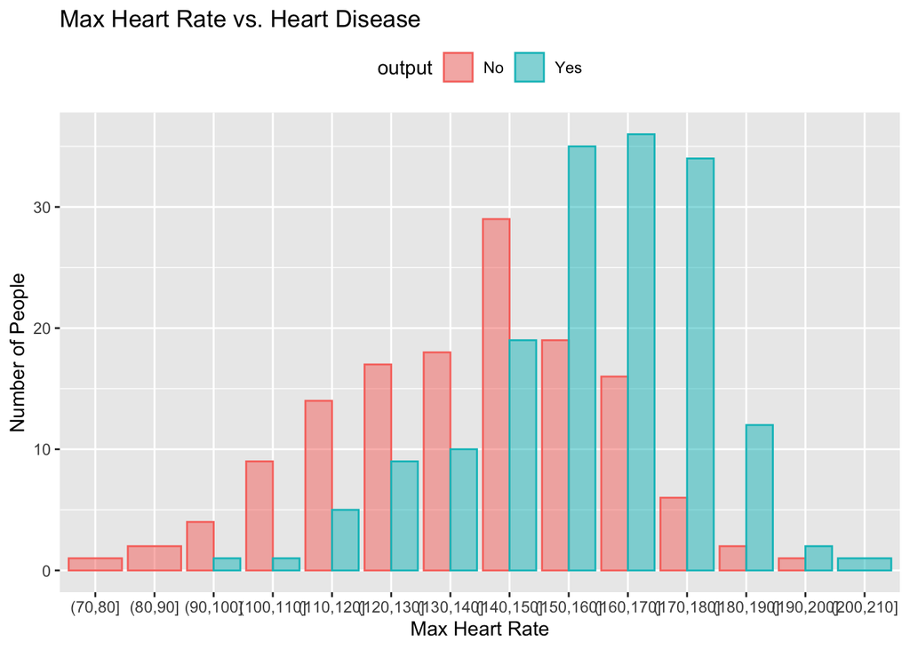

```r
heart <- heart %>%
  mutate(thalachh_class = cut(thalachh, breaks = seq(70, 210, by = 10)))
graph_thalachh <- ggplot(heart, aes(x=thalachh_class, fill = output, color = output)) +
  geom_bar(position = "dodge", alpha=0.5) +
  theme(legend.position = "top")
graph_thalachh + labs(title = "Max Heart Rate vs. Heart Disease",
                  x = "Max Heart Rate", y = "Number of People")
```

The distribution curve seems smooth and bell shaped so the data looks valid. We can see that the maximum heart rate is an important indicator for heart attack risk. Once it exceed 150, the risk of having heart attach is much higher than before. The huge difference in the mean of the two color bar shows the result as well.

### Gender

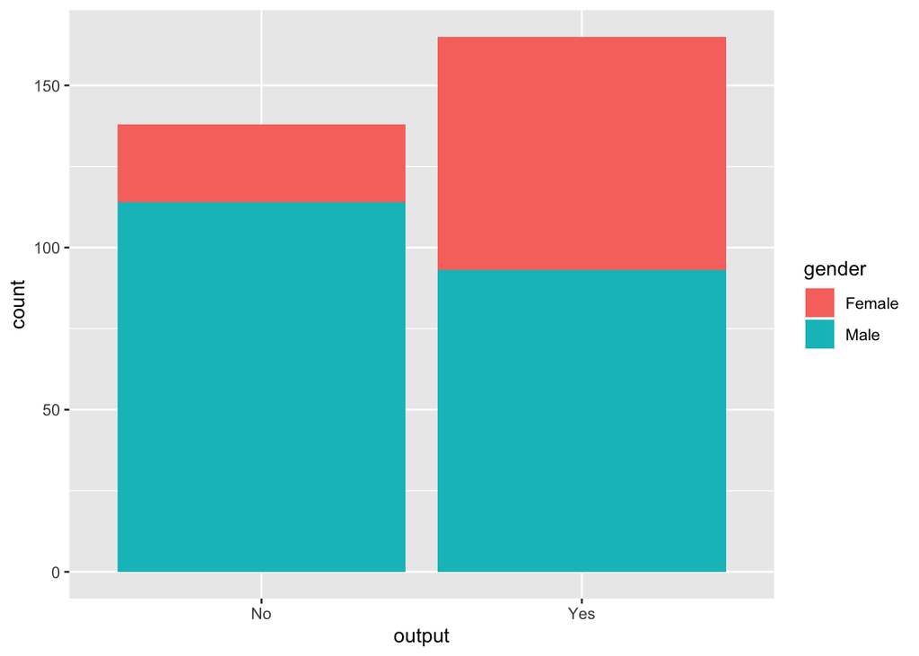

```r
heart %>%
  ggplot(aes(x = output, fill = gender)) +
  geom_bar(position = "stack")
```

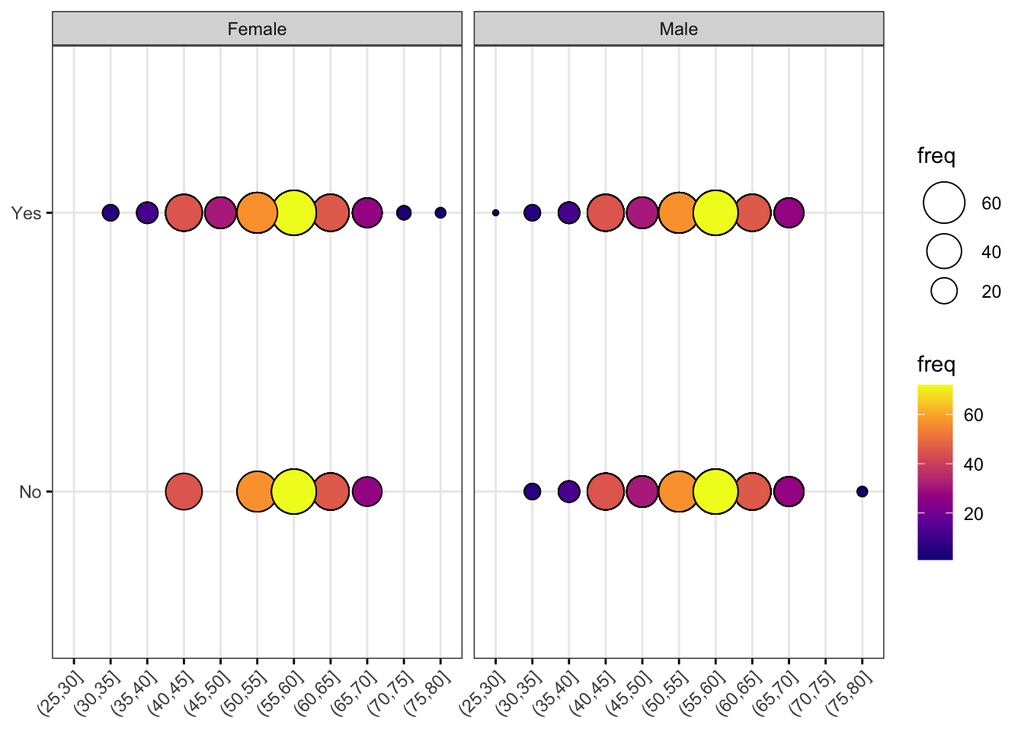

```r
heart_gender <- heart %>%
  group_by(age_class) %>%
  select(age_class, output, gender)

heart_gender <- heart_gender %>%
  transform(freq = ave(seq(nrow(heart_gender)), age_class, FUN=length))

graph_gender <- ggballoonplot(data = heart_gender, x = "age_class", y = "output", size = "freq",
                fill = "freq", facet.by = "gender",
                ggtheme = theme_bw()) + scale_fill_viridis_c(option = "C")
graph_gender
```

As mentioned before in the summary, the female is far less than male, and this might greatly influence the result. We can see here from the first graph that although male patient result in half and half, most of the female individuals has high risk of getting heart attach. This rate is imbalanced and might greatly affect the result. Also, let us take a look when we incooperate the age variable as well. We do not see a strong correlation between age and gender together with outcome.

### Chest Pain

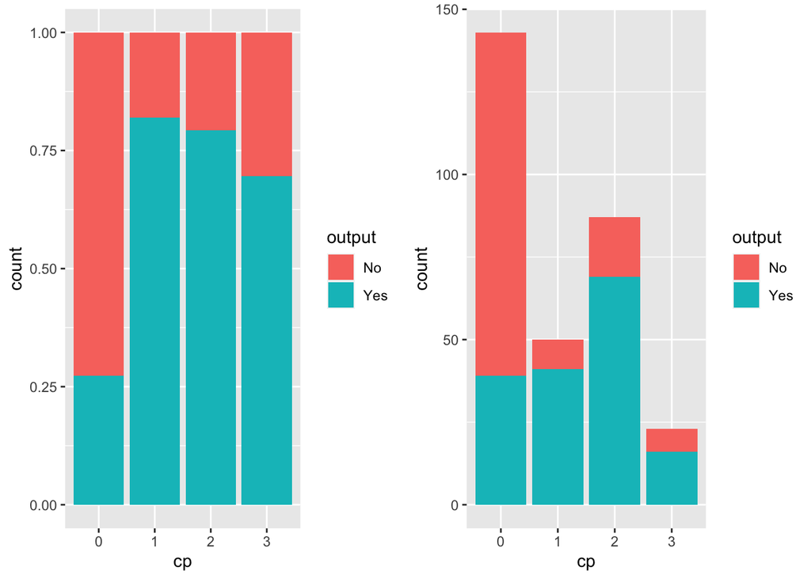

```r
cp1 <- heart %>%
  ggplot(aes(x = cp, fill = output)) +
  geom_bar(position = "fill")

cp2<- heart %>%
  ggplot(aes(x = cp, fill = output)) +
  geom_bar(position = "stack")

graph_cp <- grid.arrange(cp1,cp2, ncol = 2)
```

We see a rather strong correlation between chest pain and having a high risk of heart attack. If we consider `cp={1,2,3}` as having chest pain, this correlation is even stronger. It is very reasonable. However, we should not think is that chest pain causes heart attack. It is the other way around, chest pain might be caused by many things, however, if you have heart problem, you probably have chest pain. This means having or not having chest pain is a reasonable indicator.

### Fasting Blood Sugar

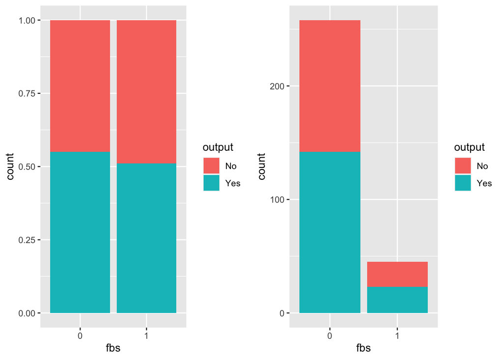

```r
fbs1<- heart %>%
  ggplot(aes(x = fbs, fill = output)) +
  geom_bar(position = "fill")

fbs2<- heart %>%
  ggplot(aes(x = fbs, fill = output)) +
  geom_bar(position = "stack")

graph_fbs <- grid.arrange(fbs1,fbs2, ncol = 2)
```

We could see from the graph that it is pretty balanced and not affected by outcome. Although there are a lot less people have blood sugar > 120, it should still not significant in out model.

### Exercise Induced Angina

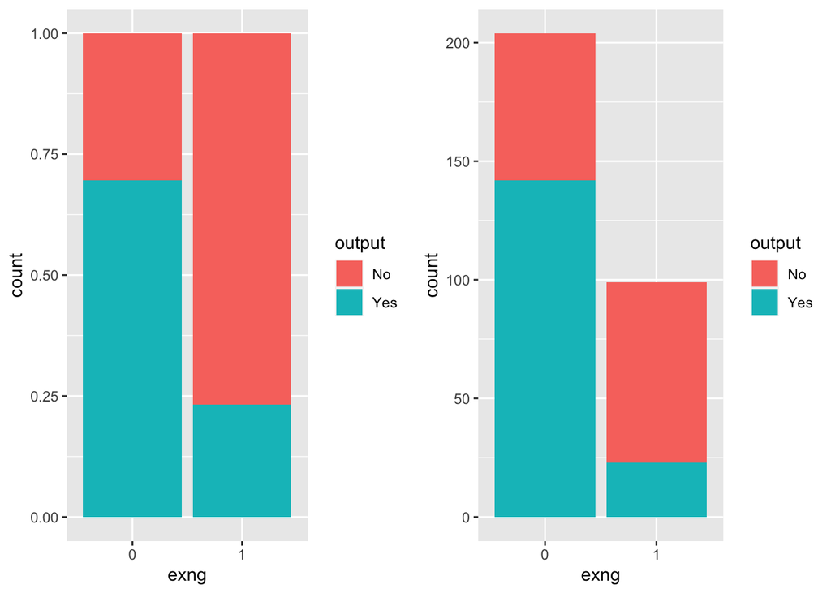

```r
exng1 <- heart %>%
  ggplot(aes(x = exng, fill = output)) +
  geom_bar(position = "fill")

exng2 <- heart %>%
  ggplot(aes(x = exng, fill = output)) +
  geom_bar(position = "stack")

graph_exng <- grid.arrange(exng1,exng2, ncol = 2)
```

We see that the portion of `No` in `exng=1` is significantly higher. This implies it might has a negative correlation with the outcome variable. This is some how counter intuitive because I think it is more seasonable to relate having angina after exercise with heart problem, which means a higher risk of having a heart attack.

### Slope

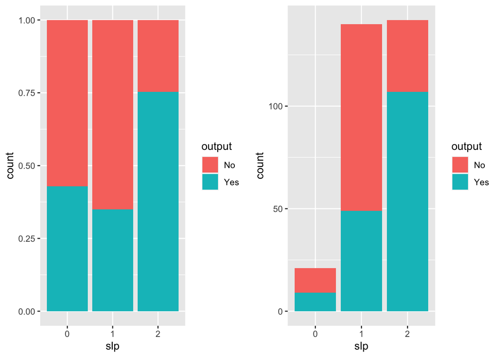

```r
slp1 <- heart %>%
  ggplot(aes(x = slp, fill = output)) +
  geom_bar(position = "fill")

slp2 <- heart %>%
  ggplot(aes(x = slp, fill = output)) +
  geom_bar(position = "stack")

graph_slp <- grid.arrange(slp1,slp2, ncol = 2)
```